# MATH 3070 Lab Project 13

Harrison Webb

08 December, 2021

*Remember: I expect to see commentary either in the text, in the code with comments created using `#`, or (preferably) both! **Failing to do so may result in lost points!***

## Problem 1 (Verzani problem 9.14)

*The data set `normtemp` (**UsingR**) contains measurements of 130 healthy, randomly selected individuals. The variable `temperature` contains normal body temperature. Does the data appear to come from a Normal distribution? If so, perform a $t$-test to see if the commonly assumed value of 98.6 degrees fahrenheit is correct. (Studies have suggested that 98.2 degrees fahrenheit is more accurate.)*

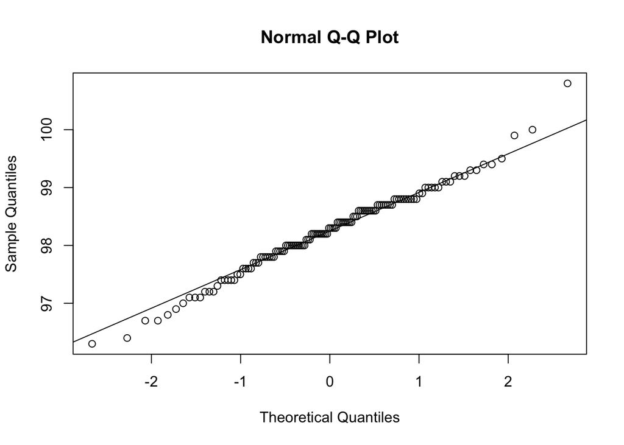

```r
#First lets check if data appears to be normally distributed
qqnorm(normtemp$temperature)
qqline(normtemp$temperature)
```

```r
#The data appear normally distributed, so we can continue with our t-test

#Two sided test; H_0: mu = 98.6, H_a: mu != 98.6
t.test(normtemp$temperature, mu = 98.6)
```

```
##
##  One Sample t-test
##
## data:  normtemp$temperature
## t = -5.4548, df = 129, p-value = 2.411e-07
## alternative hypothesis: true mean is not equal to 98.6
## 95 percent confidence interval:
##  98.12200 98.37646
## sample estimates:
## mean of x
##  98.24923
```

```r
#We get an extremely small p-value of 2.411 * 10^-7, so we reject the null hypothesis

#Lets also try a one sided test; H_0: mu = 98.6, H_a: mu < 98.6
t.test(normtemp$temperature, mu = 98.6, alternative = "less")
```

```
##
##  One Sample t-test
##
## data:  normtemp$temperature
## t = -5.4548, df = 129, p-value = 1.205e-07
## alternative hypothesis: true mean is less than 98.6
## 95 percent confidence interval:
##      -Inf 98.35577
## sample estimates:
## mean of x
##  98.24923
```

```r
#Again, the resulting p-value is extremely small and supports rejecting the null hypothesis
```

## Problem 2 (Verzani problem 9.4)

*In the United States in 2007, the proportion of adults age 21-24 who had no medical insurance was 28.1 percent. A survey of 75 recent college graduates in this age range finds that 40 percent are without insurance. Does this support a difference from the nationwide proportion? Perform a test of significance and report the p-value. Is it significant? (Perform this test “by hand”, not using `prop.test()`.)*

```r
# Your code here
#H_0: p = p_0
#H_a: p != p_0

p_0 = .281 #population proportion
p = .4 #sample proportion
n = 75 #sample size

#calculate test statistic
z = (p - p_0) / sqrt((p_0 * (1-p_0))/n )
z
```

```
## [1] 2.292767
```

```r
#calculate p value based on test statistic
pval = 2 * (1-pnorm(abs(z)))
pval
```

```
## [1] 0.0218614
```

We see that our calculated test statistic is 2.29, which corresponds to a p-value of 0.02. In order to reject the null hypothesis, we would need our level of significance set to a>=0.02 While the p-value is not overwhelmingly in favor of rejecting the null hypothesis, if we set our level of significance to a=0.05, then this result does provide sufficient evidence to reject the null hypothesis.